# A.barbata CHG NCBI

Andrés Delgado

En este documento presento algunos resultados sobre los patrones de metilación de Avena bajo distintos tratamientos de herbivoría. He usado el mismo flujo de trabajo que en avena_pseudo_results.Rmd con la diferencia de que ahora trabajamos con un genoma de referencia completo, en lugar de usar el pseudogenoma que preparé yo con stacks.

## PREPROCESSING

#### Brevemente resumo los pasos previos al análisis:

1. Se utilizó como genoma de referencia el ensamblaje Abarbata_PI388828_v1.0 (Avena barbata, GCA_947310925.1), descargado de NCBI Genome el [02/09/2025] en el siguiente enlace: https://www.ncbi.nlm.nih.gov/datasets/genome/GCA_947310925.1/
2. Alineamiento de las lecturas de bisulfito de mis muestras tratadas con el genoma de referencia usando BISMARK en linux.
3. Generación de informes de metilación de las muestras asociados a sus posiciones en el genoma de referencia. BISMARK genera estos informes en forma de archivos .bam
4. Importación de los archivos .bam a methylkit para el análisis

## SMP calling and filtering

We used “processBismarkAln” function of the methylKit R package to call all the cytosines in CHG position reported in the bam files. We removed 4481935 positions with coverage under 5 and 948 positions with coverage above 1000. This filtering step eliminated CHG sites with insufficient coverage to provide reliable methylation estimates, as well as sites with excessively high coverage likely arising from artifacts such as collapsed repetitive regions. From a total of **955521** positions, **343400** were polymorphic and therefore included in our SMP dataset. Additionally, SMPs with Minor Epiallele Frequency (MEF) ≤ 1% were removed as rare, uninformative, and potentially unreliable. Finally, we filtered the resulting **338679** SMPs to keep only those present in at least 80% of the individuals of every treatment (i.e., combinations of maternal environment and herbivory simulation treatments). After all the filters, we checked the missing data for every sample and the maximum was 3.7%. Thus, we considered unnecessary to filter by sample, resulting in **12562** SMPs ready to be analysed.

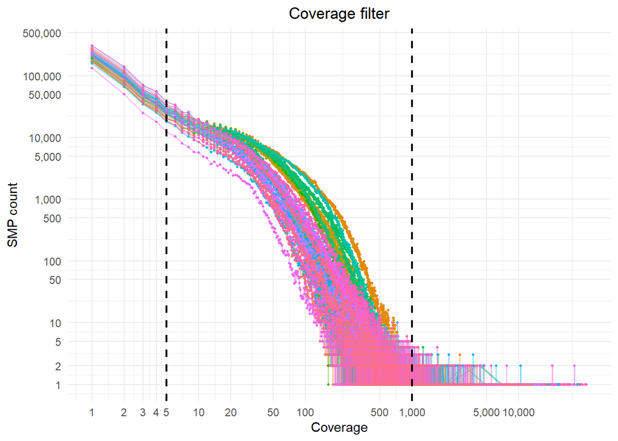

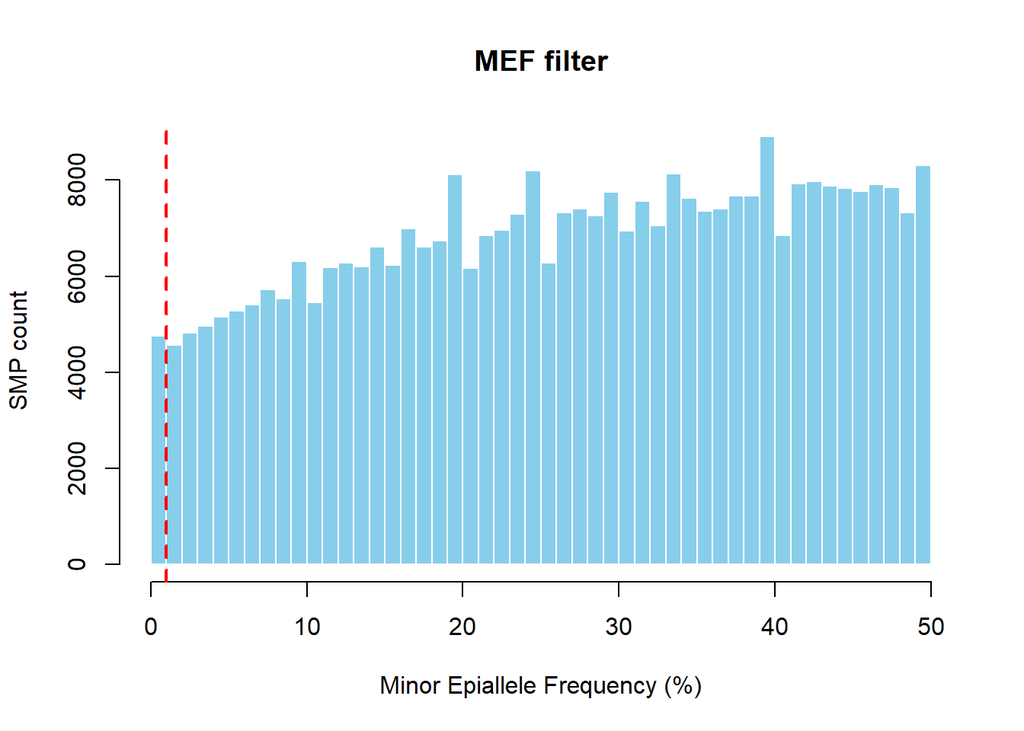

## Clustering methylation profiles

El primer paso en el análisis ha sido explorar visualmente las diferencias en los perfiles de metilación entre tratamientos. Para ello hemos utilizado los porcentajes de metilación de cada una de las posiciones CHG (posiciones del genoma con una Citosina seguida de C/T/A, seguida de una Guanina). Hemos evaluado un total de **12562** posiciones compartidas por las **42** muestras, separando por tratamientos para ver posibles agrupaciones. Aquí muestro un Correlograma, un Dendograma y un DAPC (Discriminant Analysis of Principal Components), que es un análisis multivariante usado en genética de poblaciones para describir y visualizar la estructura genética entre grupos.Utiliza el PCA y luego maximiza la separación entre grupos predefinidos (los tratamientos).

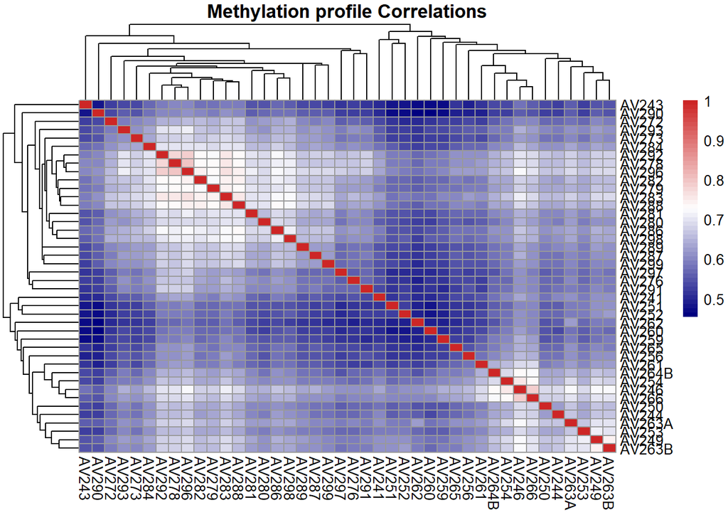

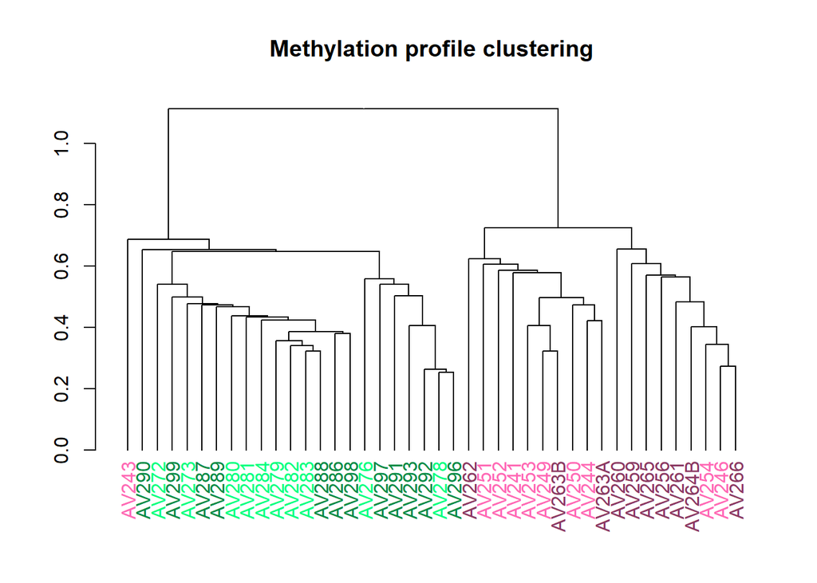

```
## Optimal number of PCs (alpha-score): 7
```

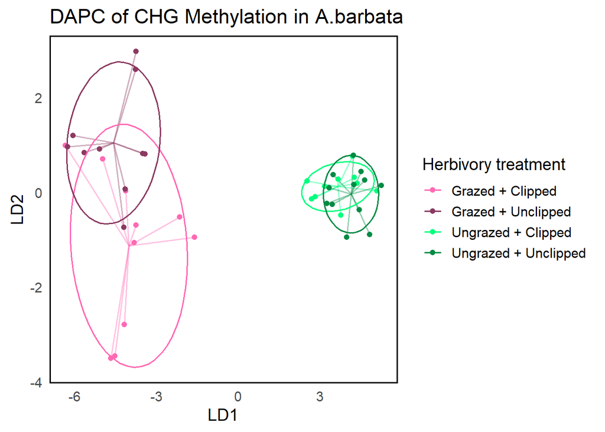

## SNP to SMP correlation

Patterns of epigenetic variation (SMPs) among individuals and populations could be similar to those of genetic variation (SNPs). To evaluate this we plot a similar DAPC with SNP data and look at the correlation between both DAPCs using procrustes analysis.

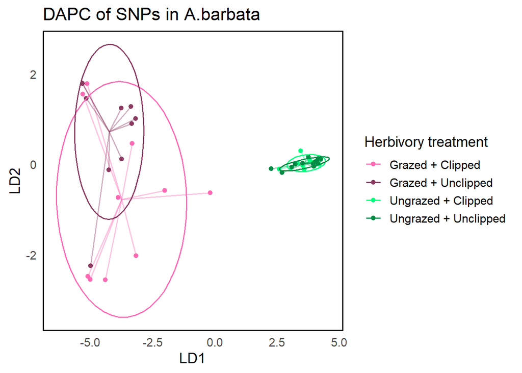

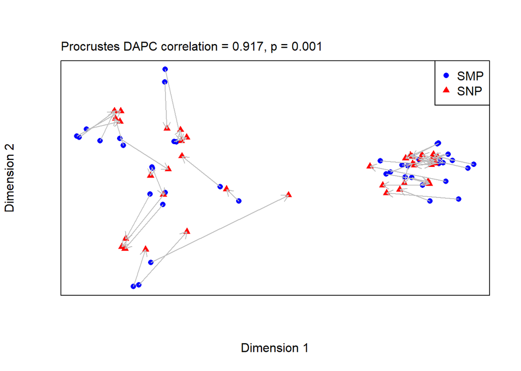

## Identifying important CHG sites

Utilizando un Loading plot podemos visualizar cuáles son las posiciones CHG más importantes en la separación entre grupos en el eje LD1.

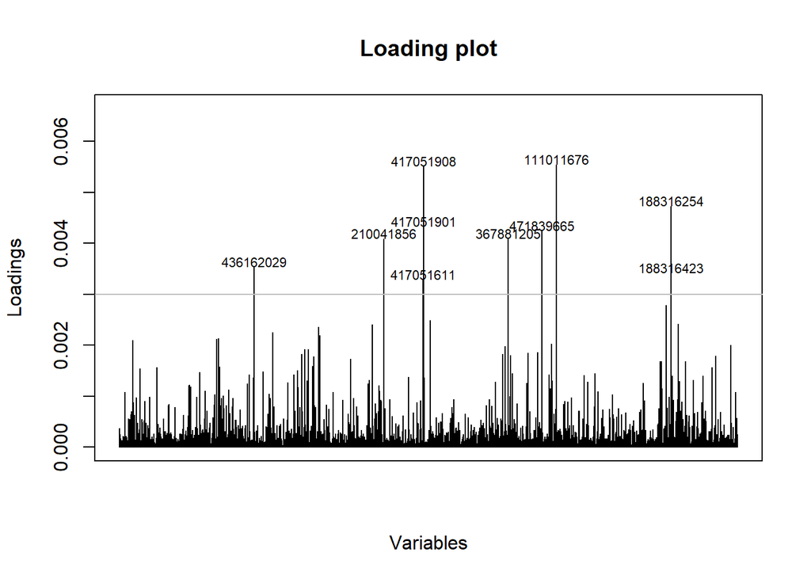

## Differential methylation analysis

Con la función “pairwise_diff()” de methylKit, podemos comparar el estado de metilación de cada citosina entre la población de cada tratamiento y la población control (Grazed es el control de Ungrazed y Unclipped es el control de Clipped). Obtenemos hipo- e hiper- metilaciones con respecto al control, y cada una de estas diferencias está asociada a un p-valor. En este caso hemos considerado como Differentially Methylated Positions (**DMPs**) cuando la **diferencia de metilación > 10%** y el **p-valor < 0.05**

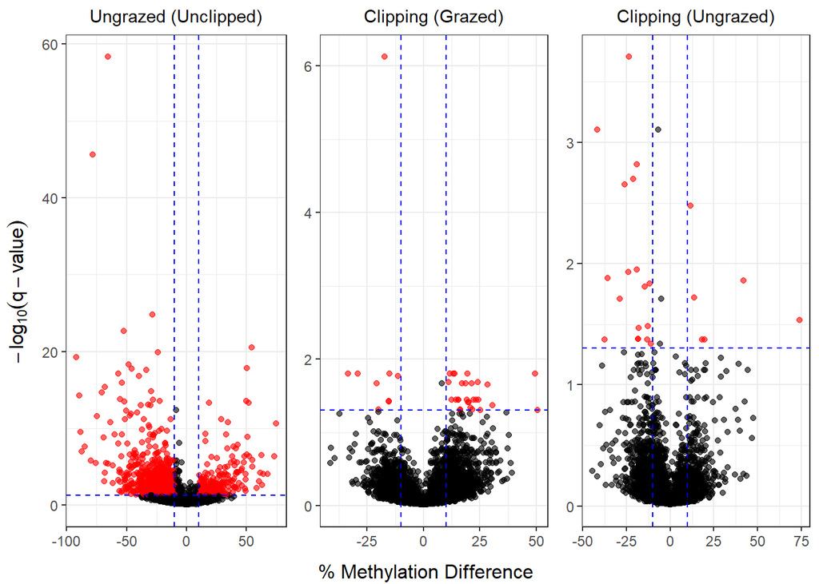

Differentially methylated sites

| Condition | UngrazedU | ClippingG | ClippingU |
| --- | --- | --- | --- |
| Hypermethylated | 253 | 28 | 6 |
| Hypomethylated | 1439 | 9 | 18 |